# Chapter-5-Exercises

[Bruce Hartman](https://drbrucehartman.net/brucewebsite/)

Last updated: 14 January, 2025

# Introduction

Solve Chapter 5 Exercises from the HEADS text.

# Packages

Regular R packages:

```r
library(tidyverse)
library(ggfortify)
library(GGally)
library(broom)
library(skimr)
library(gt)
library(patchwork)
library(yardstick)
library(car)
```

For this text:

```r
library(HEADS)
```

# Exercise 15

Catheter length.

```r
data(Table_5_9)
Table_5_9
```

| Height | Weight | CatheterLength |
| --- | --- | --- |
| 42.8 | 40.0 | 37 |
| 63.5 | 93.5 | 50 |
| 37.5 | 35.5 | 34 |
| 39.5 | 30.0 | 36 |
| 45.5 | 52.0 | 43 |
| 38.5 | 17.0 | 28 |
| 43.0 | 38.5 | 37 |
| 22.5 | 8.5 | 20 |
| 37.0 | 33.0 | 34 |
| 23.5 | 9.5 | 30 |

[output cut: 2 more lines]

Part (a):

```r
fit59 = lm(CatheterLength~Height, data=Table_5_9)
fit59 %>% glance
```

| r.squared | adj.r.squared | sigma | statistic | p.value | df | logLik | AIC | BIC | deviance | df.residual | nobs |
| --- | --- | --- | --- | --- | --- | --- | --- | --- | --- | --- | --- |
| 0.7970692 | 0.7767762 | 3.863799 | 39.27789 | 9.295117e-05 | 1 | -32.15314 | 70.30629 | 71.76101 | 149.2894 | 10 | 12 |

```r
fit59 %>% tidy()
```

| term | estimate | std.error | statistic | p.value |
| --- | --- | --- | --- | --- |
| (Intercept) | 11.4789756 | 4.09405157 | 2.803818 | 1.867185e-02 |
| Height | 0.6117124 | 0.09760525 | 6.267208 | 9.295117e-05 |

Part (b):

```r
fit59b = lm(CatheterLength~Weight, data=Table_5_9)
fit59b %>% glance
```

| r.squared | adj.r.squared | sigma | statistic | p.value | df | logLik | AIC | BIC | deviance | df.residual | nobs |
| --- | --- | --- | --- | --- | --- | --- | --- | --- | --- | --- | --- |
| 0.8181388 | 0.7999526 | 3.657721 | 44.98698 | 5.316585e-05 | 1 | -31.49542 | 68.99083 | 70.44555 | 133.7892 | 10 | 12 |

```r
fit59b %>% tidy()
```

| term | estimate | std.error | statistic | p.value |
| --- | --- | --- | --- | --- |
| (Intercept) | 25.344086 | 1.92834482 | 13.142922 | 1.236292e-07 |
| Weight | 0.283871 | 0.04232311 | 6.707233 | 5.316585e-05 |

Part (c): The models have similar R-squared values. I both cases the coefficients are significant.

Part (d): We can put both patients in the same newdata, because each regression has just one driver.

```r
ndata = data.frame(Height=52.7, Weight=77.5)

preda = predict(fit59, newdata=ndata, se.fit=T)
predb = predict(fit59b, newdata=ndata, se.fit=T)
tibble(
 lengtha = preda$fit,
 lengthb = predb$fit
)
```

| lengtha | lengthb |
| --- | --- |
| 43.71622 | 47.34409 |

# Exercise 16

| Weight | Age | BloodFatContent |
| --- | --- | --- |
| 84 | 46 | 354 |
| 73 | 20 | 190 |
| 65 | 52 | 405 |
| 70 | 30 | 263 |
| 76 | 57 | 451 |
| 69 | 25 | 302 |
| 63 | 28 | 288 |
| 72 | 36 | 385 |
| 79 | 57 | 402 |
| 75 | 44 | 365 |

[output cut: 15 more lines]

Part (a):

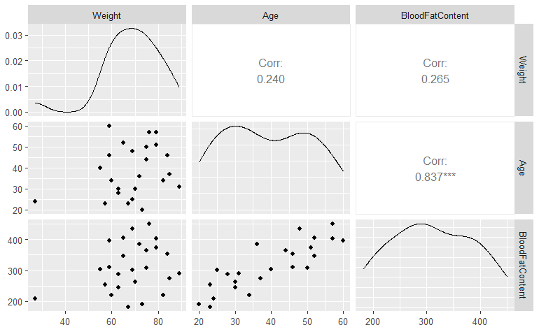

```r
Table_5_10 %>% GGally::ggpairs(progress=F)
```

Not much relation with Weight, more with Age.

```r
fit510a = lm(BloodFatContent ~ Age, data=Table_5_10)
fit510aw = lm(BloodFatContent ~ Age + Weight, data=Table_5_10)
fit510a %>% glance
```

| r.squared | adj.r.squared | sigma | statistic | p.value | df | logLik | AIC | BIC | deviance | df.residual | nobs |
| --- | --- | --- | --- | --- | --- | --- | --- | --- | --- | --- | --- |
| 0.7011607 | 0.6881677 | 43.46131 | 53.96444 | 1.794101e-07 | 1 | -128.728 | 263.4559 | 267.1126 | 43444.37 | 23 | 25 |

```r
fit510a %>% tidy
```

| term | estimate | std.error | statistic | p.value |
| --- | --- | --- | --- | --- |
| (Intercept) | 102.575142 | 29.6375713 | 3.460983 | 2.120200e-03 |
| Age | 5.320676 | 0.7242909 | 7.346049 | 1.794101e-07 |

```r
anova(fit510a, fit510aw)
```

```
Analysis of Variance Table

Model 1: BloodFatContent ~ Age
Model 2: BloodFatContent ~ Age + Weight
  Res.Df   RSS Df Sum of Sq     F Pr(>F)
1     23 43444
2     22 42806  1    638.15 0.328 0.5727
```

Age alone has an R-squared of 70%; the Age coefficient of 5.32 is significant. Adding Weight to the regression does not produce a significant improvement (p.value=.57)

# Exercise 17

```r
data(Table_5_11)
Table_5_11
```

| Cholesterol | DiastolicBloodPressure |
| --- | --- |
| 233 | 82 |
| 203 | 60 |
| 220 | 71 |
| 201 | 71 |
| 183 | 65 |
| 230 | 75 |
| 180 | 61 |
| 218 | 79 |
| 198 | 59 |
| 212 | 82 |

[output cut: 9 more lines]

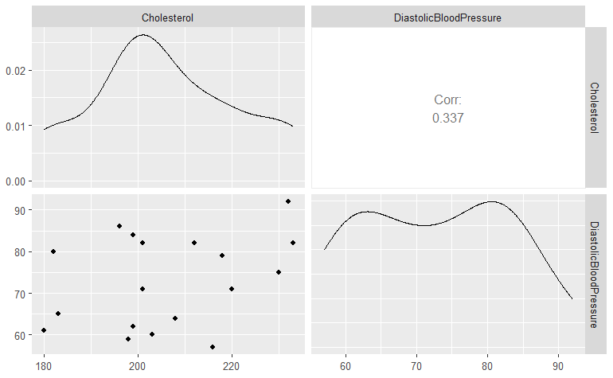

```r
Table_5_11 %>% GGally::ggpairs(progress=F)
```

```r
fit511 = lm(DiastolicBloodPressure ~ Cholesterol, data=Table_5_11)
fit511 %>% glance
```

| r.squared | adj.r.squared | sigma | statistic | p.value | df | logLik | AIC | BIC | deviance | df.residual | nobs |
| --- | --- | --- | --- | --- | --- | --- | --- | --- | --- | --- | --- |
| 0.1138709 | 0.0617457 | 10.27433 | 2.184564 | 0.1576888 | 1 | -70.16651 | 146.333 | 149.1663 | 1794.551 | 17 | 19 |

```r
fit511 %>% tidy
```

| term | estimate | std.error | statistic | p.value |
| --- | --- | --- | --- | --- |
| (Intercept) | 26.6280286 | 31.3206171 | 0.8501757 | 0.4070424 |
| Cholesterol | 0.2241992 | 0.1516882 | 1.4780272 | 0.1576888 |

R-squared is very low. Overall p.value of regression is .15, not significant. Cannot justify a relation.

# Exercise 18

```r
data(Table_5_12)
Table_5_12
```

| Age | SystolicBloodPressure |
| --- | --- |
| 20 | 120 |
| 21 | 119 |
| 22 | 129 |
| 27 | 124 |
| 29 | 138 |
| 33 | 140 |
| 34 | 160 |
| 35 | 155 |
| 40 | 143 |
| 40 | 169 |

[output cut: 10 more lines]

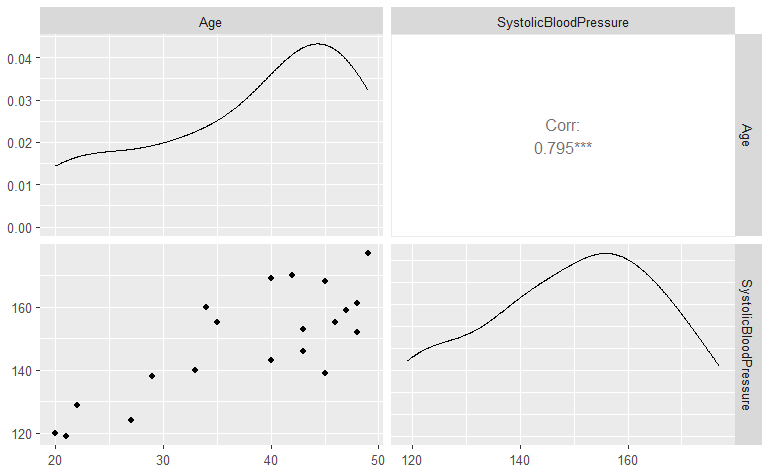

```r
Table_5_12 %>% GGally::ggpairs(progress=F)
```

Part (a):

```r
fit512 = lm(SystolicBloodPressure ~ Age, data=Table_5_12)
fit512 %>% glance
```

| r.squared | adj.r.squared | sigma | statistic | p.value | df | logLik | AIC | BIC | deviance | df.residual | nobs |
| --- | --- | --- | --- | --- | --- | --- | --- | --- | --- | --- | --- |
| 0.6312814 | 0.6107971 | 10.6726 | 30.81772 | 2.860727e-05 | 1 | -74.67875 | 155.3575 | 158.3447 | 2050.278 | 18 | 20 |

```r
fit512 %>% tidy
```

| term | estimate | std.error | statistic | p.value |
| --- | --- | --- | --- | --- |
| (Intercept) | 95.37400 | 9.9241455 | 9.610299 | 1.640665e-08 |
| Age | 1.41284 | 0.2545029 | 5.551371 | 2.860727e-05 |

The R-squared is 63%; the pairs graph shows the relation might be significant. The tidy report shows a significant coefficient of Age is 1.41 mmHg/year.

# Exercise 19

```r
data(Table_5_13)
Table_5_13
```

| BMI | SystolicBP |
| --- | --- |
| 35.28249 | 135 |
| 33.60000 | 113 |
| 20.01486 | 110 |
| 25.19153 | 115 |
| 32.91883 | 117 |
| 21.29799 | 115 |
| 21.34329 | 101 |
| 35.41000 | 132 |
| 31.62000 | 110 |
| 30.93752 | 131 |

[output cut: 18 more lines]

Part (a): We can look at this with a pairs plot, to get both a graph and correlation coefficients.

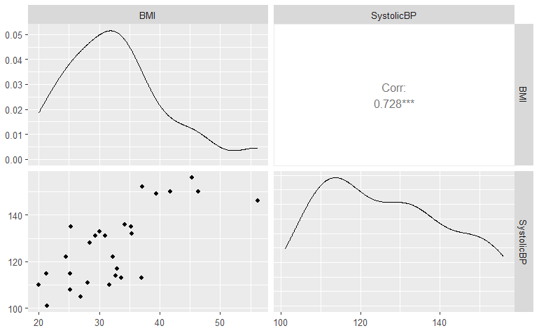

```r
Table_5_13 %>% GGally::ggpairs(progress=F)
```

Part (b):

```r
fit513 = lm(SystolicBP~BMI, data=Table_5_13)
fit513 %>% summary
```

```
Call:
lm(formula = SystolicBP ~ BMI, data = Table_5_13)

Residuals:
    Min      1Q  Median      3Q     Max
-19.889  -9.772   2.462   7.688  18.845

Coefficients:
            Estimate Std. Error t value Pr(>|t|)
(Intercept)  80.2135     8.8015   9.114 1.41e-09 ***
BMI           1.4259     0.2635   5.412 1.14e-05 ***
---
Signif. codes:  0 ‘***’ 0.001 ‘**’ 0.01 ‘*’ 0.05 ‘.’ 0.1 ‘ ’ 1

Residual standard error: 11.27 on 26 degrees of freedom
Multiple R-squared:  0.5297,    Adjusted R-squared:  0.5116
F-statistic: 29.28 on 1 and 26 DF,  p-value: 1.138e-05
```

R-squared is 52% and BMI coefficient = 1.42 is significant. There is a relation explaining about half the variation in SystolicBP.

Part (c): We use a prediction interval because it says ‘someone’, not a group.

```r
pred
```

```
       fit      lwr      upr
1 113.0081 88.89568 137.1206
```

The lower and upper confidence limits define the confidence interval in this prediction.

# Exercise 20

```r
data(Table_5_14)
Table_5_14
```

| LengthofStay | PreviousAdmissions | PatientSatisfaction |
| --- | --- | --- |
| 7 | 5 | 102 |
| 4 | 3 | 100 |
| 3 | 3 | 95 |
| 3 | 4 | 103 |
| 4 | 6 | 115 |
| 3 | 5 | 117 |
| 2 | 2 | 92 |
| 1 | 1 | 69 |
| 3 | 2 | 62 |
| 2 | 1 | 66 |

[output cut: 5 more lines]

Part (a):

```r
fit514 = lm(PatientSatisfaction~., data=Table_5_14)
fit514 %>% summary
```

```
Call:
lm(formula = PatientSatisfaction ~ ., data = Table_5_14)

Residuals:
     Min       1Q   Median       3Q      Max
-22.4895  -4.6999   0.5079   6.9299  19.0143

Coefficients:
                   Estimate Std. Error t value Pr(>|t|)
(Intercept)          59.414      9.258   6.418 3.32e-05 ***
LengthofStay          1.247      3.158   0.395  0.69994
PreviousAdmissions   10.668      3.001   3.555  0.00396 **
---
Signif. codes:  0 ‘***’ 0.001 ‘**’ 0.01 ‘*’ 0.05 ‘.’ 0.1 ‘ ’ 1

Residual standard error: 12.83 on 12 degrees of freedom
Multiple R-squared:  0.6875,    Adjusted R-squared:  0.6355
F-statistic:  13.2 on 2 and 12 DF,  p-value: 0.0009305
```

Part (b) and (c)

```r
pred = predict(fit514, newdata=data.frame(LengthofStay=2, PreviousAdmissions=8), interval="p")
pred
```

```
       fit      lwr      upr
1 147.2479 98.88907 195.6067
```

The confidence interval for this patient is satisfaction between 99 and 195. Adjusted R-squared is 63%, and PreviousAdmissions is a significant coefficient, whereas LengthOfStay is not.

# Exercise 21

```r
data(PrescriptionsData)
PrescriptionsData
```

| Week | Prescriptions |
| --- | --- |
| 1 | 2028 |
| 2 | 2036 |
| 3 | 2021 |
| 4 | 2053 |
| 5 | 2016 |
| 6 | 2052 |
| 7 | 2039 |
| 8 | 2019 |
| 9 | 2110 |
| 10 | 2108 |

[output cut: 42 more lines]

Wrangling: set dummy for week 21 on.

```r
PrescriptionsData = PrescriptionsData %>%
  mutate(MedB = case_when(
    Week >= 21 ~ 1,
    .default = 0
    ))
PrescriptionsData %>% glimpse
```

```
Rows: 52
Columns: 3
$ Week          <dbl> 1, 2, 3, 4, 5, 6, 7, 8, 9, 10, 11, 12, 13, 14, 15, 16, 17, 18, 19, 20, …
$ Prescriptions <dbl> 2028, 2036, 2021, 2053, 2016, 2052, 2039, 2019, 2110, 2108, 2069, 2158,…
$ MedB          <dbl> 0, 0, 0, 0, 0, 0, 0, 0, 0, 0, 0, 0, 0, 0, 0, 0, 0, 0, 0, 0, 1, 1, 1, 1,…
```

Regression:

```r
fit521 = lm(Prescriptions ~ ., data = PrescriptionsData)
fit521 %>% summary
```

```
Call:
lm(formula = Prescriptions ~ ., data = PrescriptionsData)

Residuals:
    Min      1Q  Median      3Q     Max
-62.058 -22.728  -3.736  20.880 101.088

Coefficients:
            Estimate Std. Error t value Pr(>|t|)
(Intercept) 2030.204      9.754  208.14  < 2e-16 ***
Week           6.357      0.583   10.90 1.05e-14 ***
MedB        -178.601     17.985   -9.93 2.54e-13 ***
---
Signif. codes:  0 ‘***’ 0.001 ‘**’ 0.01 ‘*’ 0.05 ‘.’ 0.1 ‘ ’ 1

Residual standard error: 33.96 on 49 degrees of freedom
Multiple R-squared:  0.7114,    Adjusted R-squared:  0.6996
F-statistic: 60.39 on 2 and 49 DF,  p-value: 5.993e-14
```

```r
fit521 %>% confint()
```

```
                  2.5 %      97.5 %
(Intercept) 2010.602869 2049.805089
Week           5.185164    7.528364
MedB        -214.743926 -142.457798
```

# Exercise 22

LogLikelihoods

# Exercise 23

```r
Data = data.frame(t, Prescriptions)
Data = Data %>%
  mutate(MedB = case_when(t >= 5 ~ 1, .default = 0),
         MedG = case_when(t >= 8 ~ 1, .default = 0)
  )

formula = "Prescriptions ~ t + MedB + MedG"
fit523 = lm(formula, data=Data)
```

# Exercise 24

Table 5.16

# Exercise 25

```r
data("HealthcareCostsMEPS")
HealthcareCostsMEPS %>% glimpse
```

```
Rows: 32,846
Columns: 28
$ DUPERSID                <int> 10007101, 10007102, 10007103, 10007104, 10008101, 10008102, 1…
$ SEX                     <int> 1, 2, 1, 2, 1, 2, 2, 2, 1, 2, 1, 2, 1, 2, 1, 2, 1, 1, 1, 1, 2…
$ RACE                    <int> 1, 1, 1, 1, 6, 4, 4, 2, 1, 1, 1, 1, 1, 5, 1, 6, 6, 6, 6, 1, 1…
$ FAMINC10                <dbl> 67000, 67000, 67000, 67000, 91420, 91420, 91420, 19476, 52200…
$ CONDITIONCOUNT          <int> 3, 2, 0, 0, 0, 1, 0, 2, 6, 5, 0, 0, 0, 0, 0, 1, 1, 1, 0, 2, 0…
$ AGE                     <int> 29, 26, 5, 4, 52, 54, 13, 62, 80, 76, 34, 30, 3, 27, 28, 9, 6…
$ HEALTHCOSTS             <int> 492, 1630, 74, 78, 0, 66, 55, 32984, 1870, 5284, 0, 0, 0, 124…
$ WEIGHT                  <dbl> 4859.255, 6045.316, 6776.596, 4936.364, 5834.069, 6652.286, 5…
$ SPONDYLOSISBACKPROBLEMS <int> 0, 0, 0, 0, 0, 0, 0, 0, 0, 0, 0, 0, 0, 0, 0, 0, 0, 0, 0, 0, 0…
$ JOINTDISORDERS          <int> 0, 1, 0, 0, 0, 0, 0, 0, 0, 1, 0, 0, 0, 0, 0, 0, 0, 0, 0, 0, 0…
$ DEPRESSIONBIPOLAR       <int> 0, 0, 0, 0, 0, 0, 0, 0, 0, 0, 0, 0, 0, 0, 0, 0, 0, 0, 0, 0, 0…
$ HYPERTENSION            <int> 1, 0, 0, 0, 0, 0, 0, 1, 1, 1, 0, 0, 0, 0, 0, 0, 0, 0, 0, 0, 0…
$ ANXIETYDISORDER         <int> 0, 0, 0, 0, 0, 0, 0, 1, 1, 1, 0, 0, 0, 0, 0, 0, 0, 0, 0, 0, 0…
$ DIABETES                <int> 0, 0, 0, 0, 0, 0, 0, 0, 0, 0, 0, 0, 0, 0, 0, 0, 0, 0, 0, 0, 0…
$ CONNECTIVETISSUEDISEASE <int> 0, 0, 0, 0, 0, 0, 0, 0, 0, 1, 0, 0, 0, 0, 0, 0, 0, 0, 0, 0, 0…
$ HIGHCHOLESTEROL         <int> 1, 0, 0, 0, 0, 0, 0, 0, 1, 1, 0, 0, 0, 0, 0, 0, 0, 0, 0, 0, 0…
$ COPD                    <int> 0, 0, 0, 0, 0, 0, 0, 0, 1, 0, 0, 0, 0, 0, 0, 0, 0, 0, 0, 0, 0…
$ RHEUMATOIDARTHRITIS     <int> 0, 0, 0, 0, 0, 0, 0, 0, 0, 0, 0, 0, 0, 0, 0, 0, 0, 0, 0, 0, 0…
$ UPPERRESPINFECTIONS     <int> 1, 0, 0, 0, 0, 0, 0, 0, 0, 0, 0, 0, 0, 0, 0, 1, 0, 0, 0, 0, 0…
$ ADHD                    <int> 0, 0, 0, 0, 0, 0, 0, 0, 0, 0, 0, 0, 0, 0, 0, 0, 1, 0, 0, 0, 0…
$ UPPERRESPDISEASE        <int> 0, 0, 0, 0, 0, 0, 0, 0, 1, 0, 0, 0, 0, 0, 0, 0, 0, 1, 0, 1, 0…
$ HEADACHESMIGRAINE       <int> 0, 1, 0, 0, 0, 0, 0, 0, 0, 0, 0, 0, 0, 0, 0, 0, 0, 0, 0, 0, 0…
$ NERVOUSSYSTEMDISORDERS  <int> 0, 0, 0, 0, 0, 1, 0, 0, 0, 0, 0, 0, 0, 0, 0, 0, 0, 0, 0, 0, 0…
$ ASTHMA                  <int> 0, 0, 0, 0, 0, 0, 0, 0, 1, 0, 0, 0, 0, 0, 0, 0, 0, 0, 0, 1, 0…
$ KIDNEYDISEASE           <int> 0, 0, 0, 0, 0, 0, 0, 0, 0, 0, 0, 0, 0, 0, 0, 0, 0, 0, 0, 0, 0…
$ OSTEOARTHRITIS          <int> 0, 0, 0, 0, 0, 0, 0, 0, 0, 0, 0, 0, 0, 0, 0, 0, 0, 0, 0, 0, 0…
$ KIDNEYFAILURE           <int> 0, 0, 0, 0, 0, 0, 0, 0, 0, 0, 0, 0, 0, 0, 0, 0, 0, 0, 0, 0, 0…
$ HEARTDISEASE            <int> 0, 0, 0, 0, 0, 0, 0, 0, 0, 0, 0, 0, 0, 0, 0, 0, 0, 0, 0, 0, 0…
```

Part (a):

```r
fit521a = lm(HEALTHCOSTS~AGE, data=HealthcareCostsMEPS)
fit521b = lm(HEALTHCOSTS~CONDITIONCOUNT, data=HealthcareCostsMEPS)
fit521a %>% tidy(conf.int=T)
```

| term | estimate | std.error | statistic | p.value | conf.low | conf.high |
| --- | --- | --- | --- | --- | --- | --- |
| (Intercept) | -376.0415 | 111.213418 | -3.38126 | 0.0007223822 | -594.0238 | -158.0592 |
| AGE | 106.3413 | 2.661119 | 39.96110 | 0.0000000000 | 101.1254 | 111.5571 |

```r
fit521b %>% tidy(conf.int=T)
```

| term | estimate | std.error | statistic | p.value | conf.low | conf.high |
| --- | --- | --- | --- | --- | --- | --- |
| (Intercept) | 667.5872 | 74.73179 | 8.93311 | 4.352613e-19 | 521.1102 | 814.0643 |
| CONDITIONCOUNT | 1989.4079 | 34.22634 | 58.12506 | 0.000000e+00 | 1922.3231 | 2056.4928 |

Both AGE and CONDITIONCOUNT are significant predictors of HEALTHCOSTS, with estimates of $106 per year for AGE and $1989 per condition.

Part (b):

```r
fit521m = lm(HEALTHCOSTS~.-WEIGHT-DUPERSID-HEARTDISEASE, data=HealthcareCostsMEPS)
# F-test and R-squared
fit521m %>% glance
```

| r.squared | adj.r.squared | sigma | statistic | p.value | df | logLik | AIC | BIC | deviance | df.residual | nobs |
| --- | --- | --- | --- | --- | --- | --- | --- | --- | --- | --- | --- |
| 0.1326164 | 0.1319822 | 10390.46 | 209.0869 | 0 | 24 | -350374.9 | 700801.8 | 701020.1 | 3.543407e+12 | 32821 | 32846 |

```r
fit521m %>% tidy
```

| term | estimate | std.error | statistic | p.value |
| --- | --- | --- | --- | --- |
| (Intercept) | -9.051880e+01 | 2.341923e+02 | -0.3865149 | 6.991179e-01 |
| SEX | 2.318225e+02 | 1.167650e+02 | 1.9853765 | 4.711091e-02 |
| RACE | -6.708803e+00 | 5.377521e+01 | -0.1247564 | 9.007171e-01 |
| FAMINC10 | 2.347248e-03 | 1.127031e-03 | 2.0826819 | 3.728795e-02 |
| CONDITIONCOUNT | 7.518978e+03 | 3.406861e+02 | 22.0701022 | 3.694014e-107 |
| AGE | 2.752405e+01 | 3.308498e+00 | 8.3191973 | 9.194331e-17 |
| SPONDYLOSISBACKPROBLEMS | -6.737341e+03 | 4.108165e+02 | -16.3998793 | 3.328151e-60 |
| JOINTDISORDERS | -5.919106e+03 | 3.928474e+02 | -15.0671904 | 3.948228e-51 |
| DEPRESSIONBIPOLAR | -5.043851e+03 | 4.176304e+02 | -12.0773076 | 1.639769e-33 |
| HYPERTENSION | -5.682008e+03 | 4.050706e+02 | -14.0272027 | 1.429656e-44 |

[output cut: 15 more lines]

```r
fit521m %>% summary
```

```
Call:
lm(formula = HEALTHCOSTS ~ . - WEIGHT - DUPERSID - HEARTDISEASE,
    data = HealthcareCostsMEPS)

Residuals:
   Min     1Q Median     3Q    Max
-48639  -2131   -986   -206 727254

Coefficients:
                          Estimate Std. Error t value Pr(>|t|)
(Intercept)             -9.052e+01  2.342e+02  -0.387   0.6991
SEX                      2.318e+02  1.168e+02   1.985   0.0471 *
RACE                    -6.709e+00  5.378e+01  -0.125   0.9007
FAMINC10                 2.347e-03  1.127e-03   2.083   0.0373 *
CONDITIONCOUNT           7.519e+03  3.407e+02  22.070  < 2e-16 ***
AGE                      2.752e+01  3.308e+00   8.319  < 2e-16 ***
SPONDYLOSISBACKPROBLEMS -6.737e+03  4.108e+02 -16.400  < 2e-16 ***
JOINTDISORDERS          -5.919e+03  3.928e+02 -15.067  < 2e-16 ***
DEPRESSIONBIPOLAR       -5.044e+03  4.176e+02 -12.077  < 2e-16 ***
HYPERTENSION            -5.682e+03  4.051e+02 -14.027  < 2e-16 ***
ANXIETYDISORDER         -6.193e+03  4.300e+02 -14.402  < 2e-16 ***
DIABETES                -5.331e+03  4.338e+02 -12.292  < 2e-16 ***
CONNECTIVETISSUEDISEASE -6.179e+03  4.278e+02 -14.441  < 2e-16 ***
HIGHCHOLESTEROL         -6.938e+03  4.268e+02 -16.256  < 2e-16 ***
COPD                    -5.148e+03  4.646e+02 -11.080  < 2e-16 ***
RHEUMATOIDARTHRITIS     -5.195e+03  5.739e+02  -9.053  < 2e-16 ***
UPPERRESPINFECTIONS     -7.566e+03  3.694e+02 -20.482  < 2e-16 ***
ADHD                    -6.126e+03  5.292e+02 -11.577  < 2e-16 ***
UPPERRESPDISEASE        -7.094e+03  3.989e+02 -17.783  < 2e-16 ***
HEADACHESMIGRAINE       -6.859e+03  4.419e+02 -15.523  < 2e-16 ***
NERVOUSSYSTEMDISORDERS  -3.476e+03  4.965e+02  -7.001 2.58e-12 ***
ASTHMA                  -6.058e+03  4.228e+02 -14.329  < 2e-16 ***
KIDNEYDISEASE            1.997e+02  8.413e+02   0.237   0.8124
OSTEOARTHRITIS          -5.993e+03  4.744e+02 -12.635  < 2e-16 ***
KIDNEYFAILURE            1.894e+04  1.251e+03  15.145  < 2e-16 ***
---
Signif. codes:  0 ‘***’ 0.001 ‘**’ 0.01 ‘*’ 0.05 ‘.’ 0.1 ‘ ’ 1

Residual standard error: 10390 on 32821 degrees of freedom
Multiple R-squared:  0.1326,    Adjusted R-squared:  0.132
F-statistic: 209.1 on 24 and 32821 DF,  p-value: < 2.2e-16
```

The adjusted R-squared is only 13%, but at least one coefficient is significant.

Part (c): adding interactions

```r
fit521i = lm(HEALTHCOSTS~.-WEIGHT + SEX:RACE + FAMINC10:AGE - DUPERSID- HEARTDISEASE, data=HealthcareCostsMEPS)
fit521i %>% tidy()
```

| term | estimate | std.error | statistic | p.value |
| --- | --- | --- | --- | --- |
| (Intercept) | -2.791689e+02 | 3.544509e+02 | -0.7876094 | 4.309309e-01 |
| SEX | 2.826893e+02 | 2.034247e+02 | 1.3896504 | 1.646445e-01 |
| RACE | 4.611781e+01 | 1.707204e+02 | 0.2701366 | 7.870569e-01 |
| FAMINC10 | 4.534691e-03 | 2.139924e-03 | 2.1190896 | 3.409038e-02 |
| CONDITIONCOUNT | 7.505350e+03 | 3.409324e+02 | 22.0141869 | 1.247623e-106 |
| AGE | 3.084621e+01 | 4.306872e+00 | 7.1620914 | 8.112515e-13 |
| SPONDYLOSISBACKPROBLEMS | -6.720966e+03 | 4.110782e+02 | -16.3496044 | 7.553719e-60 |
| JOINTDISORDERS | -5.911982e+03 | 3.929298e+02 | -15.0458982 | 5.436144e-51 |
| DEPRESSIONBIPOLAR | -5.032077e+03 | 4.178216e+02 | -12.0436018 | 2.464589e-33 |
| HYPERTENSION | -5.672101e+03 | 4.051619e+02 | -13.9995931 | 2.104322e-44 |

[output cut: 17 more lines]

```r
fit521i %>% glance
```

| r.squared | adj.r.squared | sigma | statistic | p.value | df | logLik | AIC | BIC | deviance | df.residual | nobs |
| --- | --- | --- | --- | --- | --- | --- | --- | --- | --- | --- | --- |
| 0.1326576 | 0.1319705 | 10390.53 | 193.0606 | 0 | 26 | -350374.1 | 700804.2 | 701039.4 | 3.543238e+12 | 32819 | 32846 |

```r
fit521i %>% summary
```

```
Call:
lm(formula = HEALTHCOSTS ~ . - WEIGHT + SEX:RACE + FAMINC10:AGE -
    DUPERSID - HEARTDISEASE, data = HealthcareCostsMEPS)

Residuals:
   Min     1Q Median     3Q    Max
-48652  -2123   -993   -183 727270

Coefficients:
                          Estimate Std. Error t value Pr(>|t|)
(Intercept)             -2.792e+02  3.545e+02  -0.788   0.4309
SEX                      2.827e+02  2.034e+02   1.390   0.1646
RACE                     4.612e+01  1.707e+02   0.270   0.7871
FAMINC10                 4.535e-03  2.140e-03   2.119   0.0341 *
CONDITIONCOUNT           7.505e+03  3.409e+02  22.014  < 2e-16 ***
AGE                      3.085e+01  4.307e+00   7.162 8.11e-13 ***
SPONDYLOSISBACKPROBLEMS -6.721e+03  4.111e+02 -16.350  < 2e-16 ***
JOINTDISORDERS          -5.912e+03  3.929e+02 -15.046  < 2e-16 ***
DEPRESSIONBIPOLAR       -5.032e+03  4.178e+02 -12.044  < 2e-16 ***
HYPERTENSION            -5.672e+03  4.052e+02 -14.000  < 2e-16 ***
ANXIETYDISORDER         -6.186e+03  4.302e+02 -14.379  < 2e-16 ***
DIABETES                -5.330e+03  4.338e+02 -12.288  < 2e-16 ***
CONNECTIVETISSUEDISEASE -6.161e+03  4.282e+02 -14.390  < 2e-16 ***
HIGHCHOLESTEROL         -6.917e+03  4.272e+02 -16.189  < 2e-16 ***
COPD                    -5.143e+03  4.647e+02 -11.066  < 2e-16 ***
RHEUMATOIDARTHRITIS     -5.198e+03  5.739e+02  -9.058  < 2e-16 ***
UPPERRESPINFECTIONS     -7.554e+03  3.696e+02 -20.440  < 2e-16 ***
ADHD                    -6.111e+03  5.294e+02 -11.544  < 2e-16 ***
UPPERRESPDISEASE        -7.078e+03  3.992e+02 -17.732  < 2e-16 ***
HEADACHESMIGRAINE       -6.841e+03  4.422e+02 -15.469  < 2e-16 ***
NERVOUSSYSTEMDISORDERS  -3.462e+03  4.966e+02  -6.971 3.22e-12 ***
ASTHMA                  -6.047e+03  4.230e+02 -14.297  < 2e-16 ***
KIDNEYDISEASE            1.987e+02  8.414e+02   0.236   0.8133
OSTEOARTHRITIS          -5.986e+03  4.745e+02 -12.615  < 2e-16 ***
KIDNEYFAILURE            1.894e+04  1.251e+03  15.142  < 2e-16 ***
SEX:RACE                -3.542e+01  1.071e+02  -0.331   0.7407
FAMINC10:AGE            -6.130e-05  5.094e-05  -1.203   0.2289
---
Signif. codes:  0 ‘***’ 0.001 ‘**’ 0.01 ‘*’ 0.05 ‘.’ 0.1 ‘ ’ 1

Residual standard error: 10390 on 32819 degrees of freedom
Multiple R-squared:  0.1327,    Adjusted R-squared:  0.132
F-statistic: 193.1 on 26 and 32819 DF,  p-value: < 2.2e-16
```

They don’t change the Adjusted R-squared very much. It actually went down. CONDITIONCOUNT and AGE are significant coefficients. Neither interaction term is significant.

Part (d): stepwise regression.

```r
library(leaps)
fit521sf = regsubsets(HEALTHCOSTS ~ . - HEARTDISEASE,
                      data=(HealthcareCostsMEPS %>% dplyr::select(-WEIGHT, -DUPERSID)),
                      method ="forward", nvmax=24)
sum521sf = summary(fit521sf)
sum521sf$cp
```

```
 [1] 1467.78318  937.46407  647.69494  528.92531  451.36950  400.40354  367.88938  339.39047
 [9]  319.18868  299.72891  287.75792  277.58755  264.23780  248.46864  235.93761  221.65028
[17]  204.28624  190.85638  161.51649  105.50077   27.01386   24.94854   23.01556   25.00000
```

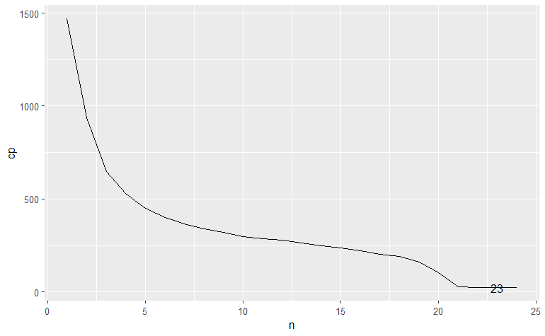

```r
x = data.frame(n=1:24, cp=round(sum521sf$cp, 3)); xlow=which.min(x$cp)
ggplot(x) +
  geom_line(aes(x=n, y=cp)) +
  annotate("text", x=xlow, y=x$cp[xlow], label=xlow)
```

```r
fit521sf %>% coef(xlow) %>% enframe(name="Driver", value="Coefficient") %>%
  mutate(Coefficient=round(Coefficient,3))
```

| Driver | Coefficient |
| --- | --- |
| (Intercept) | -101.031 |
| SEX | 231.513 |
| FAMINC10 | 0.002 |
| CONDITIONCOUNT | 7519.521 |
| AGE | 27.543 |
| SPONDYLOSISBACKPROBLEMS | -6737.337 |
| JOINTDISORDERS | -5919.582 |
| DEPRESSIONBIPOLAR | -5043.481 |
| HYPERTENSION | -5683.262 |
| ANXIETYDISORDER | -6193.032 |

[output cut: 14 more lines]

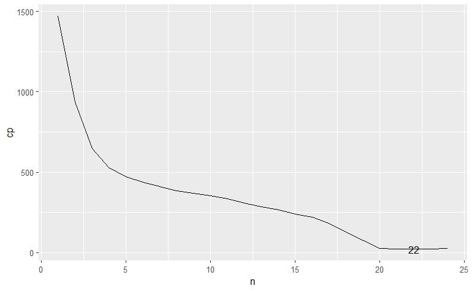

```r
library(leaps)
# have to omit one disease to keep from being degenerate
fit521sb = regsubsets(HEALTHCOSTS ~ . - HEARTDISEASE,
                      data=(HealthcareCostsMEPS %>% dplyr::select(-WEIGHT, -DUPERSID)),
                      method ="backward", nvmax=24)
# summary
sum521sb = summary(fit521sb)
# examine cp, df for graph
x = data.frame(n=1:24, cp=round(sum521sb$cp, 3)); xlow=which.min(x$cp)
ggplot(x) +
  geom_line(aes(x=n, y=cp)) +
  annotate("text", x=xlow, y=x$cp[xlow], label=xlow)
```

```r
# display coefficients of best fit
fit521sb %>% coef(xlow) %>% enframe(name="Driver", value="Coefficient") %>%
  mutate(Coefficient=round(Coefficient,3))
```

| Driver | Coefficient |
| --- | --- |
| (Intercept) | -101.121 |
| SEX | 231.993 |
| FAMINC10 | 0.002 |
| CONDITIONCOUNT | 7555.123 |
| AGE | 27.523 |
| SPONDYLOSISBACKPROBLEMS | -6773.031 |
| JOINTDISORDERS | -5954.596 |
| DEPRESSIONBIPOLAR | -5079.238 |
| HYPERTENSION | -5719.438 |
| ANXIETYDISORDER | -6229.627 |

[output cut: 13 more lines]

# Exercise 26

James Lopez Bernal, Steven Cummins, and Antonio Gasparrini. Interrupted time series regression for the evaluation of public health interventions: a tutorial. Int J Epidemiol., 46:348–355, 2017.

# Exercise 27

# Exercise 32

```r
data(Covid2020)
Covid2020
```

Wrangle date:

```r
Covid2020 = Covid2020 %>% mutate(Date = mdy(DATE_OF_INTEREST), .after=1)
```

Plots:

```r
ggplot(Covid2020) +
  geom_line(aes(Date,Cases), color="blue") +
  geom_line(aes(Date,Hospitalizations), color="red") +
  geom_point(aes(Date,Deaths), color="black")
```

[output not shown]

# References

Mehrotra, Sanjay, Kevin Bui, and Hari Balasubramanian (2024). Healthcare Engineering, Analytics, and Decision Sciences: An Introduction. December 11, 2024. (https://sites.google.com/view/healthcareengineering/)